# Zadatak 4

0036555596 Roko Grgurić

2026-01-21

# Istraživačko pitanje: Možemo li naslutiti kako je film ocijenjen pomoću drugih značajki?

U ovoj analizi istražujemo možemo li pomoću dostupnih značajki filmova (godina izlaska, trajanje, žanr i content rating) pouzdano predvidjeti IMDb ocjenu. Cilj je izgraditi model višestruke linearne regresije koji će omogućiti razumijevanje koje karakteristike utječu na ocjenu i koliko taj utjecaj snažan.

```r
oscars <- read.csv("oscars_dataset.csv", sep = ";")
```

# Opis problema

Jedno od pitanja koje razmatramo je možemo li naslutiti kako je film ocijenjen na temelju drugih dostupnih značajki. Cilj je izgraditi model koji će omogućiti predikciju IMDb ocjene koristeći godinu izlaska filma, trajanje, žanr i content ratinga filma kao prediktore.

# Priprema podataka za analizu

Najprije moramo provjeriti nedostajuće podatke i osigurati da su tipovi varijabli ispravni.

```r
data.frame(
  Varijabla = c("IMDB.Rating", "Year.of.Release", "Movie.Time", "Main.Genre", "Content.Rating"),
  Broj_vrijednosti = c(
    sum(oscars$IMDB.Rating != ""),
    sum(oscars$Year.of.Release != ""),
    sum(oscars$Movie.Time != ""),
    sum(oscars$Main.Genre != ""),
    sum(oscars$Content.Rating != "")
  )
)
```

| Varijabla | Broj_vrijednosti |
| --- | --- |
| IMDB.Rating | 571 |
| Year.of.Release | 571 |
| Movie.Time | 571 |
| Main.Genre | 571 |
| Content.Rating | 459 |

```r
oscars$IMDB.Rating <- as.numeric(as.character(oscars$IMDB.Rating))
oscars$Year.of.Release <- as.numeric(as.character(oscars$Year.of.Release))
oscars$Movie.Time <- as.numeric(as.character(oscars$Movie.Time))

oscars_clean <- oscars[complete.cases(oscars[, c("IMDB.Rating", "Year.of.Release",
                                                   "Movie.Time", "Main.Genre",
                                                   "Content.Rating")]), ]
```

# Deskriptivna statistika

Numeričke varijable

```r
summary(oscars_clean[, c("IMDB.Rating", "Year.of.Release", "Movie.Time")])
```

```
##   IMDB.Rating   Year.of.Release   Movie.Time
##  Min.   :5.60   Min.   :1927    Min.   : 66.0
##  1st Qu.:7.30   1st Qu.:1944    1st Qu.:107.0
##  Median :7.60   Median :1972    Median :121.0
##  Mean   :7.57   Mean   :1973    Mean   :124.9
##  3rd Qu.:7.90   3rd Qu.:2001    3rd Qu.:136.5
##  Max.   :9.30   Max.   :2021    Max.   :238.0
```

Mjere centralne tendencije i rasipanja

```r
data.frame(
  Varijabla = c("IMDB.Rating", "Year.of.Release", "Movie.Time"),
  Mean = c(
    mean(oscars_clean$IMDB.Rating, na.rm = TRUE),
    mean(oscars_clean$Year.of.Release, na.rm = TRUE),
    mean(oscars_clean$Movie.Time, na.rm = TRUE)
  ),
  Median = c(
    median(oscars_clean$IMDB.Rating, na.rm = TRUE),
    median(oscars_clean$Year.of.Release, na.rm = TRUE),
    median(oscars_clean$Movie.Time, na.rm = TRUE)
  ),
  SD = c(
    sd(oscars_clean$IMDB.Rating, na.rm = TRUE),
    sd(oscars_clean$Year.of.Release, na.rm = TRUE),
    sd(oscars_clean$Movie.Time, na.rm = TRUE)
  ),
  IQR = c(
    IQR(oscars_clean$IMDB.Rating, na.rm = TRUE),
    IQR(oscars_clean$Year.of.Release, na.rm = TRUE),
    IQR(oscars_clean$Movie.Time, na.rm = TRUE)
  )
)
```

| Varijabla | Mean | Median | SD | IQR |
| --- | --- | --- | --- | --- |
| IMDB.Rating | 7.570403 | 7.6 | 0.5596518 | 0.6 |
| Year.of.Release | 1973.357268 | 1972.0 | 29.3157379 | 57.0 |
| Movie.Time | 124.894921 | 121.0 | 26.3228170 | 29.5 |

# Korelacijska matrica

Računamo korelacijsku matricu za ispitivanje linearnih odnosa između naših numeričkih varijabli.

```r
cor_matrix <- cor(oscars_clean[, c("IMDB.Rating", "Movie.Time", "Year.of.Release")],
                  use = "complete.obs")
print(round(cor_matrix, 3))
```

```
##                 IMDB.Rating Movie.Time Year.of.Release
## IMDB.Rating           1.000      0.292           0.330
## Movie.Time            0.292      1.000           0.242
## Year.of.Release       0.330      0.242           1.000
```

Korelacijska matrica pokazuje odnose između numeričkih prediktora. Pozitivna korelacija između godine izlaska i IMDb ocjene ukazuje na to da noviji filmovi teže imati više ocjene.

# Scatter plot: IMDb ocjena vs trajanje filma

Grafički prikaz odnosa između trajanja filma i IMDb ocjene pomoću dijagrama raspršenja.

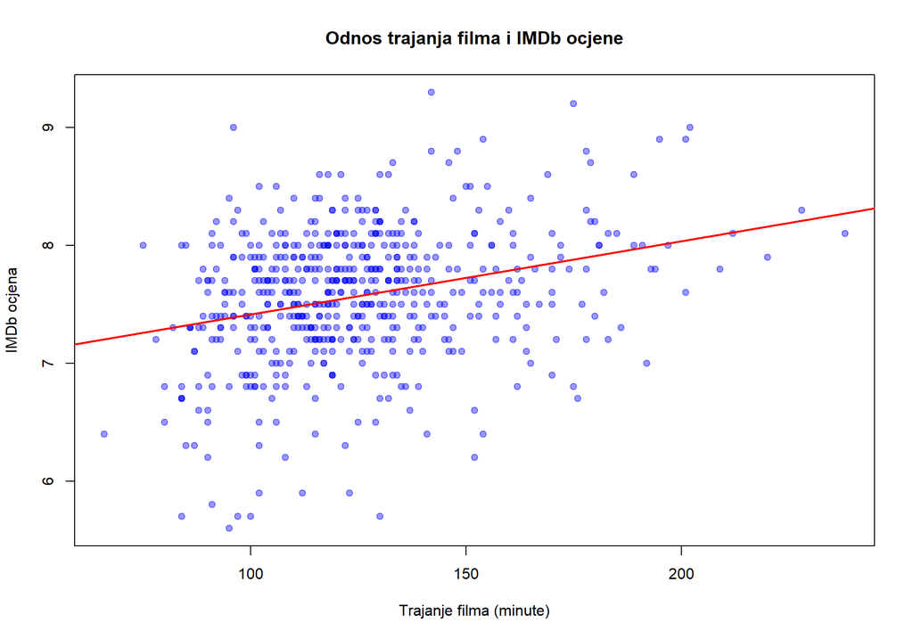

```r
plot(oscars_clean$Movie.Time, oscars_clean$IMDB.Rating,
     main = "Odnos trajanja filma i IMDb ocjene",
     xlab = "Trajanje filma (minute)",
     ylab = "IMDb ocjena",
     pch = 19, col = rgb(0, 0, 1, 0.4))

abline(lm(IMDB.Rating ~ Movie.Time, data = oscars_clean),
       col = "red", lwd = 2)
```

Iz scatter plota možemo vidjeti blagu pozitivnu vezu između trajanja filma i ocjene. Crvena linija predstavlja linearnu regresiju.

# Model višestruke linearne regresije

Sada ćemo izgraditi model koristeći višestruku linearnu regresiju.

# Priprema dummy varijabli

Budući da kategorijske varijable ne mogu direktno ući u linearni regresijski model, potrebno ih je transformirati u dummy varijable.

```r
oscars_model <- fastDummies::dummy_cols(oscars_clean,
                                        select_columns = c("Main.Genre", "Content.Rating"),
                                        remove_first_dummy = TRUE,
                                        remove_selected_columns = FALSE)

names(oscars_model) <- make.names(names(oscars_model))

# Pregled dostupnih dummy varijabli
genre_cols <- grep("^Main.Genre_", names(oscars_model), value = TRUE)
rating_cols <- grep("^Content.Rating_", names(oscars_model), value = TRUE)
```

Dummy varijable omogućuju uključivanje kategorijskih varijabli u model tako da svaka kategorija dobiva svoju indikatorsku varijablu. Važno je izostaviti jednu dummy varijablu iz svake kategorijske varijable kako bi se izbjegla multikolinearnost.

# Procjena modela

```r
base_predictors <- c("Year.of.Release", "Movie.Time")
all_predictors <- c(base_predictors, genre_cols, rating_cols)

cat("Broj prediktora u modelu:", length(all_predictors), "\n")
```

```
## Broj prediktora u modelu: 20
```

```r
cat("Prvih 5 dummy varijabli:\n")
```

[output not shown]

```r
print(head(all_predictors, 10))
```

```
##  [1] "Year.of.Release"      "Movie.Time"           "Main.Genre_Adventure"
##  [4] "Main.Genre_Animation" "Main.Genre_Biography" "Main.Genre_Comedy"
##  [7] "Main.Genre_Crime"     "Main.Genre_Drama"     "Main.Genre_Family"
## [10] "Main.Genre_Film.Noir"
```

```r
model_formula <- reformulate(termlabels = all_predictors,
                              response = "IMDB.Rating")

fit.multi <- lm(model_formula, data = oscars_model)

summary(fit.multi)
```

```
##
## Call:
## lm(formula = model_formula, data = oscars_model)
##
## Residuals:
##      Min       1Q   Median       3Q      Max
## -1.64027 -0.30374  0.01772  0.33585  1.49495
##
## Coefficients:
##                        Estimate Std. Error t value Pr(>|t|)
## (Intercept)           3.1592144  2.3170669   1.363 0.173297
## Year.of.Release       0.0018122  0.0011910   1.522 0.128685
## Movie.Time            0.0052093  0.0008615   6.047 2.73e-09 ***
## Main.Genre_Adventure -0.0380734  0.1091455  -0.349 0.727349
## Main.Genre_Animation  0.7457589  0.3056128   2.440 0.014993 *
## Main.Genre_Biography -0.0764575  0.0927162  -0.825 0.409934
## Main.Genre_Comedy     0.0080785  0.0944425   0.086 0.931864
## Main.Genre_Crime      0.2992392  0.1078003   2.776 0.005693 **
## Main.Genre_Drama      0.0024800  0.0863247   0.029 0.977091
## Main.Genre_Family     0.4499028  0.4999644   0.900 0.368583
## Main.Genre_Film.Noir  0.1689826  0.3578175   0.472 0.636929
## Main.Genre_Horror     0.1869882  0.2953578   0.633 0.526938
## Main.Genre_Music     -1.4016225  0.5005105  -2.800 0.005284 **
## Main.Genre_Musical   -0.9306681  0.3598880  -2.586 0.009966 **
## Main.Genre_Romance   -0.3943736  0.5007340  -0.788 0.431275
## Main.Genre_Western   -1.0622698  0.3575178  -2.971 0.003096 **
## Content.Rating_G      0.0304803  0.0876661   0.348 0.728209
## Content.Rating_NR     0.1073793  0.0687248   1.562 0.118756
## Content.Rating_PG     0.2584658  0.0750049   3.446 0.000612 ***
## Content.Rating_PG.13  0.2915523  0.0938619   3.106 0.001993 **
## Content.Rating_R      0.3063185  0.0805032   3.805 0.000158 ***
## ---
## Signif. codes:  0 '***' 0.001 '**' 0.01 '*' 0.05 '.' 0.1 ' ' 1
##
## Residual standard error: 0.4906 on 550 degrees of freedom
## Multiple R-squared:  0.2585, Adjusted R-squared:  0.2315
## F-statistic: 9.587 on 20 and 550 DF,  p-value: < 2.2e-16
```

Model višestruke linearne regresije procjenjuje IMDb ocjenu kao funkciju godine izlaska, trajanja filma, žanra i content ratinga. Dummy varijable predstavljaju razlike u ocjenama između pojedinih žanrova i content ratinga u odnosu na referentnu kategoriju.

Iz sažetka modela možemo iščitati da su neki koeficijenti statistički značajni (p < 0.05), što znači da imaju značajan utjecaj na IMDb ocjenu. Adjusted R² pokazuje koliki postotak varijance u ocjenama model objašnjava, prilagođeno za broj parametara.

# Testovi regresijskih koeficijenata i adjusted R²

```r
adj_r2 <- summary(fit.multi)$adj.r.squared
f_stat <- summary(fit.multi)$fstatistic
f_pval <- pf(f_stat[1], f_stat[2], f_stat[3], lower.tail = FALSE)

cat("Adjusted R²:", round(adj_r2, 4), "\n")
```

```
## Adjusted R²: 0.2315
```

```r
cat("F-statistika:", round(f_stat[1], 2), "\n")
```

```
## F-statistika: 9.59
```

```r
cat(sprintf("p-vrijednost: %.4e\n\n", f_pval))
```

```
## p-vrijednost: 3.1573e-25
```

```r
coef_summary <- summary(fit.multi)$coefficients
significant_coefs <- sum(coef_summary[, 4] < 0.05, na.rm = TRUE)
total_coefs <- nrow(coef_summary)

cat("Broj značajnih koeficijenata (p < 0.05):", significant_coefs, "od", total_coefs, "\n")
```

```
## Broj značajnih koeficijenata (p < 0.05): 9 od 21
```

F-test pokazuje da je model statistički značajan i pruža bolju predikciju od nul-modela.

# Predikcija srednje vrijednosti

Koristimo procijenjeni model za predikciju IMDb ocjene za “prosječan” film.

```r
new_data <- data.frame(
  Year.of.Release = median(oscars_clean$Year.of.Release, na.rm = TRUE),
  Movie.Time = median(oscars_clean$Movie.Time, na.rm = TRUE)
)

# Dodavanje dummy varijabli (sve na 0 za referentne kategorije)
for (col in c(genre_cols, rating_cols)) {
  new_data[[col]] <- 0
}

pred_mean <- predict(fit.multi, newdata = new_data,
                     interval = "confidence", level = 0.95)

cat("Predikcija IMDb ocjene za prosječan film:\n")
```

```
## Predikcija IMDb ocjene za prosječan film:
```

```r
cat("Godina izlaska:", new_data$Year.of.Release, "\n")
```

```
## Godina izlaska: 1972
```

```r
cat("Trajanje:", new_data$Movie.Time, "minuta\n")
```

```
## Trajanje: 121 minuta
```

```r
cat("Referentni žanr i rating\n\n")
```

```
## Referentni žanr i rating
```

```r
cat("Predviđena ocjena:", round(pred_mean[1], 3), "\n")
```

```
## Predviđena ocjena: 7.363
```

```r
cat("95% interval pouzdanosti: [",
    round(pred_mean[2], 3), ",", round(pred_mean[3], 3), "]\n")
```

```
## 95% interval pouzdanosti: [ 7.181 , 7.545 ]
```

Interval pouzdanosti od 95% znači da smo 95% uvjereni da će se prava srednja vrijednost IMDb ocjene za filmove s ovim karakteristikama nalaziti unutar navedenog intervala.

# Analiza reziduala

Prije donošenja konačnih zaključaka o modelu, potrebno je provjeriti pretpostavke linearne regresije analizom reziduala.

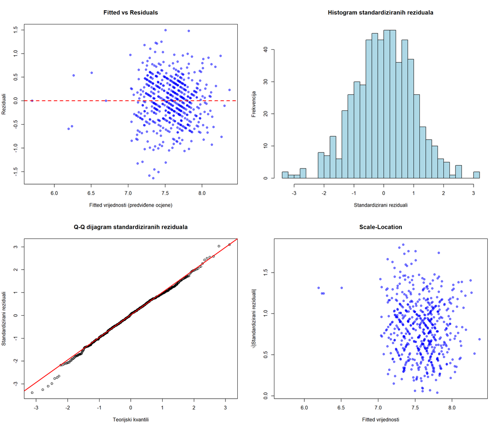

```r
par(mfrow = c(2, 2))

plot(fit.multi$fitted.values, fit.multi$residuals,
     main = "Fitted vs Residuals",
     xlab = "Fitted vrijednosti (predviđene ocjene)",
     ylab = "Reziduali",
     pch = 19, col = rgb(0, 0, 1, 0.5))
abline(h = 0, col = "red", lwd = 2, lty = 2)

# 2. Histogram reziduala
hist(rstandard(fit.multi), breaks = 25,
     main = "Histogram standardiziranih reziduala",
     xlab = "Standardizirani reziduali",
     ylab = "Frekvencija",
     col = "lightblue")

# 3. Q-Q plot
qqnorm(rstandard(fit.multi),
       main = "Q-Q dijagram standardiziranih reziduala",
       xlab = "Teorijski kvantili",
       ylab = "Standardizirani reziduali")
qqline(rstandard(fit.multi), col = "red", lwd = 2)

# 4. Scale-Location
plot(fit.multi$fitted.values, sqrt(abs(rstandard(fit.multi))),
     main = "Scale-Location",
     xlab = "Fitted vrijednosti",
     ylab = "√|Standardizirani reziduali|",
     pch = 19, col = rgb(0, 0, 1, 0.5))
```

```r
par(mfrow = c(1, 1))
```

Q-Q plot pokazuje da reziduali uglavnom prate dijagonalnu liniju, s blagim odstupanjima na krajevima, što sugerira da pretpostavka normalnosti nije značajno narušena.

# Test normalnosti reziduala

Provjerimo sada normalnost reziduala Lillieforsovom inačicom Kolmogorov-Smirnovljevog testa na razini značajnosti od 5% uz sljedeće hipoteze:

H0: Reziduali su normalno distribuirani H1: Reziduali nisu normalno distribuirani.

```r
nortest::lillie.test(rstandard(fit.multi))
```

```
##
##  Lilliefors (Kolmogorov-Smirnov) normality test
##
## data:  rstandard(fit.multi)
## D = 0.025402, p-value = 0.5007
```

Testna statistika pokazuje p-vrijednost. Ako je p-vrijednost veća od 0.05, test nije statistički značajan te nemamo dovoljno dokaza za odbacivanje nul-hipoteze. Reziduali se mogu smatrati normalno distribuiranima.

# Bootstrap analiza

Bootstrap se koristi radi **robusnosti procjena**. Omogućuje procjenu intervala pouzdanosti bez striktnih pretpostavki o distribuciji podataka, što je posebno korisno kada pretpostavke normalnosti mogu biti narušene.

```r
set.seed(42)

formula_string <- paste("IMDB.Rating ~", paste(all_predictors, collapse = " + "))

bootstrap_lm <- function(data, indices) {
  d <- data[indices, ]
  fit <- lm(as.formula(formula_string), data = d)
  return(coef(fit))
}

# Bootstrap s 1000 iteracija

boot_results <- boot::boot(data = oscars_model,
                           statistic = bootstrap_lm,
                           R = 1000)
```

# Bootstrap intervali pouzdanosti

Bootstrap intervali pouzdanosti za sve koeficijente modela:

```r
coef_names <- names(coef(fit.multi))
bootstrap_intervals <- data.frame(
  Koeficijent = coef_names,
  Procjena = round(coef(fit.multi), 4),
  OLS_SE = round(summary(fit.multi)$coefficients[, "Std. Error"], 4),
  Boot_SE = round(apply(boot_results$t, 2, sd, na.rm = TRUE), 4),
  Boot_Lower = numeric(length(coef_names)),
  Boot_Upper = numeric(length(coef_names)),
  stringsAsFactors = FALSE
)

for (i in 1:length(coef_names)) {
  tryCatch({
    boot_ci <- boot::boot.ci(boot_results, type = "perc", index = i)
    if (!is.null(boot_ci$percent)) {
      bootstrap_intervals$Boot_Lower[i] <- round(boot_ci$percent[4], 4)
      bootstrap_intervals$Boot_Upper[i] <- round(boot_ci$percent[5], 4)
    }
  }, error = function(e) {
    bootstrap_intervals$Boot_Lower[i] <- NA
    bootstrap_intervals$Boot_Upper[i] <- NA
  })
}

print(bootstrap_intervals)
```

```
##                               Koeficijent Procjena OLS_SE Boot_SE Boot_Lower
## (Intercept)                   (Intercept)   3.1592 2.3171  2.3583    -1.3825
## Year.of.Release           Year.of.Release   0.0018 0.0012  0.0012    -0.0005
## Movie.Time                     Movie.Time   0.0052 0.0009  0.0009     0.0035
## Main.Genre_Adventure Main.Genre_Adventure  -0.0381 0.1091  0.1245    -0.2940
## Main.Genre_Animation Main.Genre_Animation   0.7458 0.3056  0.1396     0.4712
## Main.Genre_Biography Main.Genre_Biography  -0.0765 0.0927  0.1029    -0.2888
## Main.Genre_Comedy       Main.Genre_Comedy   0.0081 0.0944  0.1073    -0.2274
## Main.Genre_Crime         Main.Genre_Crime   0.2992 0.1078  0.1243     0.0477
## Main.Genre_Drama         Main.Genre_Drama   0.0025 0.0863  0.0994    -0.2048
## Main.Genre_Family       Main.Genre_Family   0.4499 0.5000  0.1127     0.2255
## Main.Genre_Film.Noir Main.Genre_Film.Noir   0.1690 0.3578  0.1211    -0.0822
## Main.Genre_Horror       Main.Genre_Horror   0.1870 0.2954  0.1231    -0.0432
## Main.Genre_Music         Main.Genre_Music  -1.4016 0.5005  0.1156    -1.6366
## Main.Genre_Musical     Main.Genre_Musical  -0.9307 0.3599  0.4091    -1.6057
## Main.Genre_Romance     Main.Genre_Romance  -0.3944 0.5007  0.1181    -0.6259
## Main.Genre_Western     Main.Genre_Western  -1.0623 0.3575  0.4788    -1.8324
## Content.Rating_G         Content.Rating_G   0.0305 0.0877  0.0956    -0.1532
## Content.Rating_NR       Content.Rating_NR   0.1074 0.0687  0.0767    -0.0519
## Content.Rating_PG       Content.Rating_PG   0.2585 0.0750  0.0764     0.1081
## Content.Rating_PG.13 Content.Rating_PG.13   0.2916 0.0939  0.0856     0.1212
## Content.Rating_R         Content.Rating_R   0.3063 0.0805  0.0802     0.1428
##                      Boot_Upper
## (Intercept)              7.6535
## Year.of.Release          0.0042
## Movie.Time               0.0068
## Main.Genre_Adventure     0.1972
## Main.Genre_Animation     1.0122
## Main.Genre_Biography     0.1237
## Main.Genre_Comedy        0.2164
## Main.Genre_Crime         0.5562
## Main.Genre_Drama         0.2061
## Main.Genre_Family        0.6659
## Main.Genre_Film.Noir     0.4045
## Main.Genre_Horror        0.4380
## Main.Genre_Music        -1.1930
## Main.Genre_Musical      -0.2553
## Main.Genre_Romance      -0.1740
## Main.Genre_Western      -0.2767
## Content.Rating_G         0.2222
## Content.Rating_NR        0.2645
## Content.Rating_PG        0.4174
## Content.Rating_PG.13     0.4558
## Content.Rating_R         0.4580
```

# Vizualizacija Bootstrap distribucija

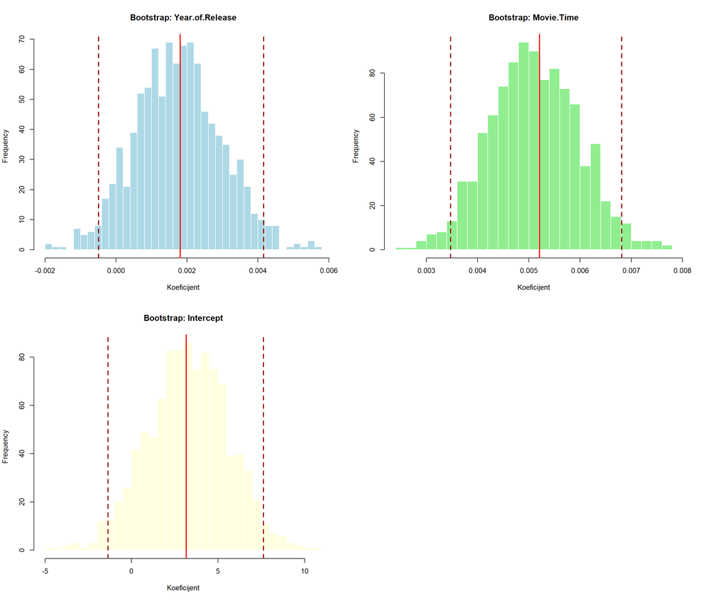

```r
par(mfrow = c(2, 2))

# Bootstrap za Year.of.Release
if (ncol(boot_results$t) >= 2) {
  hist(boot_results$t[, 2], breaks = 30,
       main = "Bootstrap: Year.of.Release",
       xlab = "Koeficijent",
       col = "lightblue",
       border = "white")
  abline(v = coef(fit.multi)[2], col = "red", lwd = 2)
  abline(v = quantile(boot_results$t[, 2], c(0.025, 0.975), na.rm = TRUE),
         col = "darkred", lwd = 2, lty = 2)
}

# Bootstrap za Movie.Time
if (ncol(boot_results$t) >= 3) {
  hist(boot_results$t[, 3], breaks = 30,
       main = "Bootstrap: Movie.Time",
       xlab = "Koeficijent",
       col = "lightgreen",
       border = "white")
  abline(v = coef(fit.multi)[3], col = "red", lwd = 2)
  abline(v = quantile(boot_results$t[, 3], c(0.025, 0.975), na.rm = TRUE),
         col = "darkred", lwd = 2, lty = 2)
}

# Bootstrap za Intercept
hist(boot_results$t[, 1], breaks = 30,
     main = "Bootstrap: Intercept",
     xlab = "Koeficijent",
     col = "lightyellow",
     border = "white")
abline(v = coef(fit.multi)[1], col = "red", lwd = 2)
abline(v = quantile(boot_results$t[, 1], c(0.025, 0.975), na.rm = TRUE),
       col = "darkred", lwd = 2, lty = 2)

par(mfrow = c(1, 1))
```

Crvena linija označava procjenu koeficijenta iz originalnog modela, dok isprekidane linije označavaju 95% bootstrap interval pouzdanosti.

# Zaključak

Model višestruke linearne regresije koristi godinu izlaska filma, trajanje filma, žanr i content rating za predikciju IMDb ocjene nominiranih filmova za Oscara.

Adjusted R² iznosi 0.2315, što znači da model objašnjava 23.15% varijance u IMDb ocjenama. F-test pokazuje da je model statistički značajan (p < 0.001), što znači da korištene značajke imaju prediktivnu moć.

Iako model objašnjava značajan dio varijabilnosti, preostala neobjašnjena varijanca ukazuje na to da postoje i drugi faktori (kvaliteta režije, gluma, priča) koji utječu na ocjene, a nisu uključeni u ovaj model.